# econ2200Ch10 slides

## ECON2200H

### Introduction to Statistics for Economics and Management

### 2020 Winter Term

### Week 09: Testing Hypothesis: comparing distributions

#### 9 March 2020, revised on 10 March 2020

### Reading: Chapter 10 of textbook.

## Outline

- Testing hypothesis using two samples

## 0. Introduction

- We often compare two distributions (populations), e.g. whether two population means are different.
- Example. Are the mean hourly wage rates equal between a plumber and an electrician?
- Example. Whether annual salaries of new graduates from two universities are different.
- We can perform hypothesis testing, using random samples drawn respectively from different populations.
- There are two situations: two random samples are independent, or are dependent.

## 1. Comparing two population means using independent samples

- Assume two random samples are independent: meaning their joint distribution equals the product of two distributions. [We did not learn joint distribution].
- Let $X_1, X_2, \cdots, X_m$ be a random sample of size $m$ drawn from a normal distribution with mean $\mu_X$ and standard deviation $\sigma_X$.
- Let $Y_1, Y_2, \cdots, Y_n$ be a random sample of size $n$ drawn from another normal distribution with mean $\mu_Y$ and standard deviation $\sigma_Y$.
- We want to test if $\mu_X - \mu_Y =0$, or $\mu_X - \mu_Y \le 0$, $\mu_X - \mu_Y \ge 0$.
- Sample means are $\overline{X} = \frac{1}{m} \sum_{i=1}^m X_i$, $\overline{Y} = \frac{1}{n}\sum_{i=1}^n Y_i$.
- **Claim: If the two samples respectively drawn from normal distributions, then the difference of sample means, $\overline{X} - \overline{Y}$, has a normal distribution.**
- The independence of two samples implies that the variance of $\overline{X} - \overline{Y}$ is given by $$\sigma_{\overline{X} - \overline{Y}}^2 = \frac{\sigma_X^2}{m} + \frac{\sigma_Y^2}{n}.$$
- (Optional). $\text{var}(\overline{X} - \overline{Y}) = \text{var}(\overline{X}) + \text{var}(\overline{Y}) - 2 \text{cov}(\overline{X},\overline{Y})$, where $\text{cov}()$ is the co-variance of $\overline{X}$ and $\overline{Y}$, $\text{cov}()$ is zero for two independent random samples. Then $(\sigma_{\overline{X} - \overline{Y}})^2 = (\sigma_{\overline{X}})^2 + (\sigma_{\overline{Y}})^2$. Recall, $(\sigma_{\overline{X}})^2 = (\sigma_{X})^2 / m$.

### 1-1. Testing the difference of population mean when $\sigma_X$ and $\sigma_Y$ are known

- The test statistic $$Z = \frac{(\overline{X} - \overline{Y}) - (\mu_X -\mu_Y)}{\sqrt{\frac{\sigma_X^2}{m} + \frac{\sigma_Y^2}{n}}}$$ has a standard normal distribution.
- A special case is $\sigma_X = \sigma_Y$.
- Example. Two payment methods: cash and automatic payment machine, comparison of mean times of payment.

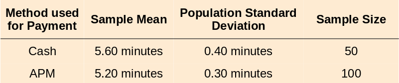

- Denote $\overline{X} = 5.6$ and $\overline{Y} = 5.2$.
- Null and alternative hypotheses: $$H_0: \mu_X-\mu_Y\le 0 \\ H_1: \mu_X-\mu_Y > 0.$$ It's a right-tailed test.
- Select 0.01 significance level.
- Select the test statistic: $Z$.
- Formulate the decision rule: reject the null if the value of $Z$ is greater than 2.33.
- Make a decision: $Z = \frac{(5.6-5.2) - 0}{\sqrt{\frac{0.4^2}{50} + \frac{0.3^2}{100}}}=6.25$, which is greater than 2.33. Thus, we reject the null hypothesis at 0.01 significance level.
- Conclusion: automatic payment machine is faster in processing payment than cash.

### 1-2. Testing the difference of population mean when $\sigma_X$ = $\sigma_Y=\sigma$ with unknown $\sigma$

- Generally, population standard deviations are unknown.
- Suppose that population standard deviations are equal but unknown, let $\sigma_X$ = $\sigma_Y=\sigma$.
- We then use an estimate of the population standard deviation, using both samples, it can be shown that the pooled sample variance is $$s_p^2 = \frac{(m-1)s_{X}^2 + (n-1)s_{Y}^2}{m+n-2},$$ where $s_{X}^2$ is the sample variance, $s_X^2 = \frac{1}{(m-1)} \sum_{i=1}^m (X_i - \overline{X})^2$; also $s_Y^2 = \frac{1}{(n-1)} \sum_{i=1}^n (Y_i - \overline{Y})^2$.
- **Claim**: If two random samples are independent and both are drawn from two independent normal distributions, the two normal distributions have the same variance. Then the test statistic $$T = \frac{(\overline{X} - \overline{Y}) - (\mu_X -\mu_Y)}{\sqrt{\frac{s_p^2}{m} + \frac{s_p^2}{n}}}$$ has a $t$ distribution with $(m+n-2)$ degrees of freedom.
- The reason to replace both $\sigma_X$ and $\sigma_Y$ with $s_p$ is that we assume $\sigma_X=\sigma_Y=\sigma$. $s_p$ is an estimate of $\sigma$ using two independent samples.
- Example. Riding time on a biking path of 2 kilometers in a city park. Comparing mean riding time for two brands of bicycles.

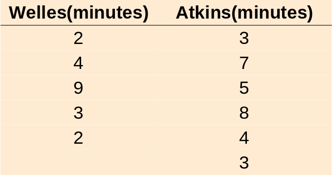

- Use $X$ for riding times in the left column, $Y$ for riding times on the right.
- Sample size $m=5$, $n=6$.
- Step 1, formulate hypotheses $$H_0: \mu_X - \mu_Y = 0 \\ H_1: \mu_X - \mu_Y \ne 0.$$
- Step 2, select significance level, let it be 0.1.
- Step 3, Select test statistic. Use $t$ statistic.
- Step 4, Formulate a decision rule: reject $H_0$ if $T$ is not between -1.833 and 1.833.

[figure not shown]

- Step 5, Make a decision. $s_X = \sqrt{\frac{\sum_{i=1}^5 X_i^2 -(\sum_{i=1}^5 X_i)^2/5}{5-1}}=2.9155$; $s_Y = 2.0976$. Then the pooled sample standard deviation $s_p = \sqrt{\frac{(5-1) \cdot 2.9155^2 + (6-1) \cdot 2.0976^2}{5+6-2}} = \sqrt{6.2222} = 2.4944$. The test statistic is then $T = \frac{(\overline{X} - \overline{Y}) - (\mu_X -\mu_Y)}{s_p \sqrt{\frac{1}{5} + \frac{1}{6}}} = -0.662$.
- The test statistic (-0.662) is not in the rejection region. Failed to reject $H_0$.

## 2. Comparing population means using dependent samples

- Consider **paired samples**.
- Example. To measure the effectiveness of a new diet, we would weigh the dieters at the start and at the finish of the program. The weight at finish depends on that at the start, the sample is paired (one at the start, one at the finish).
- Example. Treatment experiment. Two groups: treated group and control group. Subjects between two groups are matched by say age, weight, or gender. Compare treatment effect for say the same age, same weight, or same gender.
- E.g., Two groups of the unemployed, one participates in a training program, one does not.
- Goal again is to compare the difference of population means.
- Here, we only look at the case of **unknown population standard deviation**.

-Use the same notations as in Section 1. For the $i$-th paired sample (observation), define the difference as $D_i = X_i - Y_i$. Let $n$ be the size of paired samples.

- $D_i$ is a random variable. Its expected value (mean) is $\mu_D = \mu_X - \mu_Y$.
- Then, a natural estimate of $\mu_X - \mu_Y$ is $\overline{D} = \overline{X} - \overline{Y}$.
- **Claim**: Statistic $T = \frac{\overline{D} - \mu_D}{s_D / \sqrt{n}}$ has a $t$ distribution with (n-1) degrees of freedom.
- Here, $s_D$ is the sample standard deviation of differences, and $s_D = \sqrt{\frac{\sum_{i=1}^n D_i^2 -\frac{(\sum_{i=1}^n D_i)^2}{n}}{n-1}}$.
- NOTE: the sample standard deviation $s_D$ is different from when samples are independent.
- We did not give an expression for $\sigma_D$, for your information, it depends on the correlation between two subjects in the pair which we did not study.
- **Example**. Compare the mean price of real estate properties developed by two firms: Schadek and Bowyer.

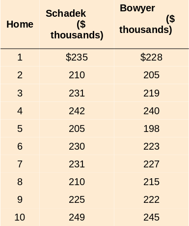

- Hypotheses $$H_0: \mu_D=0 \\ H_1: \mu_D \ne 0.$$
- Choose significance level to be 0.05.
- Use the test statistic $T = \frac{\overline{D} - 0}{s_D / \sqrt{n}}$.
- The decision rule: reject $H_0$ if the value of $T$ is not between -2.262 and 2.262.
- By calculation, $\overline{D} = 4.6$, $s_D = 4.402$, and $T=3.305$.
- Decision/Conclusion: Reject $H_0$, since the value $3.305$ is not between 2.262 and 2.262.

## 3. Comparing two population proportions

[figure not shown]